# Ft Riley avian point transects

Initial investigations of Ft Riley 2020 avian survey.

Rexstad (CREEM, University of St Andrews)https://www.creem.st-andrews.ac.uk/  
2021-10-24

Load the packages to be used

```r
library(Distance)
library(readxl)
library(knitr)
library(plotrix)
library(kableExtra)
```

There are also a couple of functions I will define here to be used later in our analysis.

```r
cvmtest <- function(dsobject) {
#  Small function that prints Cramer-von Mises test and associated P-value
  cvmw <- round(gof_ds(dsobject, plot=FALSE)$dsgof$CvM$W, 3)
  cvmp <- round(gof_ds(dsobject, plot=FALSE)$dsgof$CvM$p, 3)
  print(paste("CvM W=", cvmw, "P=", cvmp))
}

visitplot <- function(dsobject) {
# plots visit-specific detection functions
  plot(dsobject, pdf=TRUE, showpoints=FALSE, main="Detection function with visit as covariate")
  add_df_covar_line(dsobject, data=data.frame(bout=as.factor(1)),
                    pdf=TRUE, lty=1, col="blue")
  add_df_covar_line(dsobject, data=data.frame(bout=as.factor(2)),
                    pdf=TRUE, lty=1, col="green")
  add_df_covar_line(dsobject, data=data.frame(bout=as.factor(3)),
                    pdf=TRUE, lty=1, col="red")
  legend("topright", lty=1, legend=c("Visit 1", "Visit 2", "Visit 3"),
         col=c("blue", "green", "red"))
}
```

Acquire data from the spreadsheet. Note how `na=` argument is used.

```r
spreadsheet.file <- "BBS_Observations_Master.xlsx"
birds <- as.data.frame(read_xlsx(path=spreadsheet.file, sheet="Observaitons", na="NA"))
```

Make adjustments to column names to conform to convention used in the `Distance` package.

```r
names(birds)[7] <- "obsname"
birds$Effort <- birds$effort
birds$Region.Label <- birds$Region
birds$Sample.Label <- birds$pid
birds$Area <- 1
```

Specify units of measure. With point transects there are no distances associated with `Effort`, that argument is set to `NULL`.

```r
birdunits <- convert_units("meter", NULL, "square kilometer")
```

Some quick exploration of the data shows Bout 3 is missing information about two stations; what are they? Presumably there were no detections at these stations on the third visit. Data will need to be adjusted accordingly because the data file implies two stations were not visited on the third bout.

```r
all.stns <- seq(from=0, to=100)
length(unique(birds$pid[birds$bout==2]))
```

```
[1] 101
```

```r
stations.bout2 <- unique(birds$pid[birds$bout==2])
setdiff(all.stns, stations.bout2)
```

```
integer(0)
```

```r
length(unique(birds$pid[birds$bout==3]))
```

```
[1] 99
```

```r
stations.bout3 <- unique(birds$pid[birds$bout==3])
setdiff(all.stns, stations.bout3)
```

```
[1] 23 56
```

# Detections by species and visit

There are several species of interest (according to KEM, 13Oct21 email): Henslow’s Sparrow (HESP), Northern Bobwhite (NOBO), Pheasant (RNPH), Dickcissel (DICK). Species with many detections include Brown-headed cowbird (BHCO), Eastern meadowlark (EAME) and Bell’s vireo (BEVI).

Investigate number of detections that might support bout-specific detection functions

```r
special.species <- c("HESP", "NOBO", "RNPH", "DICK", "BHCO", "EAME", "BEVI")
detect.table <- data.frame()
for (spec in seq_along(1: length(special.species))) {
  detect.table <- rbind(detect.table, as.vector(table(birds$bout[birds$species==special.species[spec]])))
}
names(detect.table) <- c("bout1", "bout2", "bout3")
row.names(detect.table) <- special.species
kable(detect.table, caption="Detections by visit", row.names = TRUE) %>%
  kable_paper(bootstrap_options = "striped", full_width = FALSE)
```

Table 1: Detections by visit

|  | bout1 | bout2 | bout3 |
| --- | --- | --- | --- |
| HESP | 10 | 15 | 20 |
| NOBO | 70 | 178 | 103 |
| RNPH | 14 | 34 | 1 |
| DICK | 270 | 318 | 243 |
| BHCO | 146 | 150 | 49 |
| EAME | 115 | 93 | 92 |
| BEVI | 112 | 54 | 43 |

```r
each.visit.alone <- function(mydata, spname, mytrunc, myunits) {
  thisspp <- mydata[(mydata$species==spname & mydata$bout==1)  | is.na(mydata$distance), ]
  this.unic <- ds(data=thisspp,
                  transect="point", key="unif", adjustment = "cos",
                  truncation = mytrunc, convert.units = myunits)
  this.hnc <- ds(data=thisspp,
                  transect="point", key="hn", adjustment = "cos",
                  truncation = mytrunc, convert.units = myunits)
  this.hrc <- ds(data=thisspp,
                  transect="point", key="hr", adjustment = "cos", order=NULL,
                  truncation = mytrunc, convert.units = myunits)
  kable(summarize_ds_models(this.unic, this.hnc, this.hrc)[,2:7],
        caption="Visit 1", digits=3, row.names = FALSE)
  bout1 <- this.hrc$dht$individuals$D
# visit2
  thisspp <- mydata[(mydata$species==spname & mydata$bout==2)  | is.na(mydata$distance), ]
  this.unic <- ds(data=thisspp,
                  transect="point", key="unif", adjustment = "cos",
                  truncation = mytrunc, convert.units = myunits)
  this.hnc <- ds(data=thisspp,
                  transect="point", key="hn", adjustment = "cos",
                  truncation = mytrunc, convert.units = myunits)
  this.hrc <- ds(data=thisspp,
                  transect="point", key="hr", adjustment = "cos",
                  truncation = mytrunc, convert.units = myunits)
  kable(summarize_ds_models(this.unic, this.hnc, this.hrc)[,2:7],
        caption="Visit 2", digits=3, row.names = FALSE)
  bout2 <- this.hrc$dht$individuals$D
# visit3
  thisspp <- mydata[(mydata$species==spname & mydata$bout==3)  | is.na(mydata$distance), ]
  this.unic <- ds(data=thisspp,
                  transect="point", key="unif", adjustment = "cos",
                  truncation = mytrunc, convert.units = myunits)
  this.hnc <- ds(data=thisspp,
                  transect="point", key="hn", adjustment = "cos",
                  truncation = mytrunc, convert.units = myunits)
  this.hrc <- ds(data=thisspp,
                  transect="point", key="hr", adjustment = "cos",
                  truncation = mytrunc, convert.units = myunits)
  kable(summarize_ds_models(this.unic, this.hnc, this.hrc)[,2:7],
        caption="Visit 3", digits=3, row.names = FALSE)
  bout3 <- this.hrc$dht$individuals$D
  ests <- rbind(bout1, bout2, bout3)
  ests$Label <- c("Visit 1", "Visit 2", "Visit 3")
#  kable(ests, caption=paste("Visit-specific density estimates for", spname), digits = 3)
  return(ests)
}
```

# Northern bobwhite

## Each visit treated separately

```r
birds$Effort <- 1
mytruncation <- "10%"
bobwhite <- each.visit.alone(birds, "NOBO", mytruncation, birdunits)
```

## Temporal estimate plot

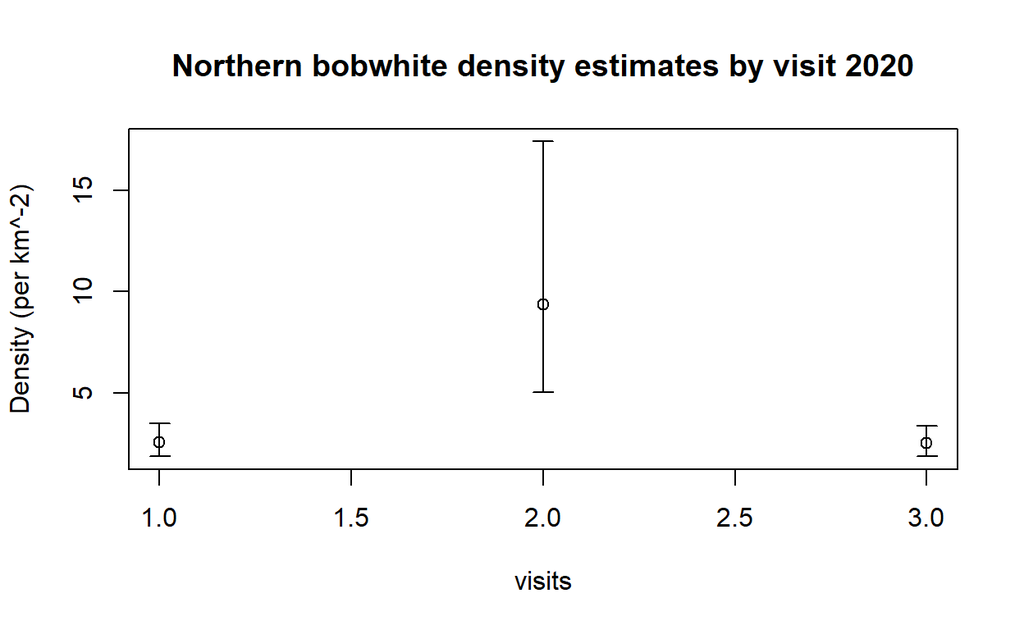

Figure 1: Northern bobwhite density estimates by time

```r
visits <- c(1,2,3)
plotCI(visits, bobwhite$Estimate, li=bobwhite$lcl, ui=bobwhite$ucl, ylab="Density (per km^-2)",
       main="Northern bobwhite density estimates by visit 2020")
```

## Pooled across visits

Make sure to adjust effort properly, combining all visits implies effort is equal to number of visits.

```r
birds$Effort <- 3
nobo <- birds[(birds$species=="NOBO")  | is.na(birds$distance), ]
nobopool <- ds(data=nobo,
                transect="point", key="hr", adjustment = "cos",
                truncation = mytruncation, convert.units = birdunits)
summary(nobopool)
```

```
Summary for distance analysis
Number of observations :  321
Distance range         :  0  -  400

Model : Hazard-rate key function
AIC   : 3791.47

Detection function parameters
Scale coefficient(s):
            estimate         se
(Intercept) 5.690258 0.06355212

Shape coefficient(s):
            estimate        se
(Intercept) 1.379326 0.2323667

                       Estimate         SE         CV
Average p             0.6850825  0.0475801 0.06945163
N in covered region 468.5566866 35.6982992 0.07618779

Summary statistics:
  Region Area CoveredArea Effort   n   k       ER      se.ER
1   FRMR    1    152.3044    303 321 101 1.059406 0.08590373
      cv.ER
1 0.0810867

Abundance:
  Label Estimate        se        cv      lcl      ucl       df
1 Total 3.076449 0.3284544 0.1067641 2.494599 3.794011 257.1558

Density:
  Label Estimate        se        cv      lcl      ucl       df
1 Total 3.076449 0.3284544 0.1067641 2.494599 3.794011 257.1558
```

```r
cvmtest(nobopool)
```

```
[1] "CvM W= 0.27 P= 0.165"
```

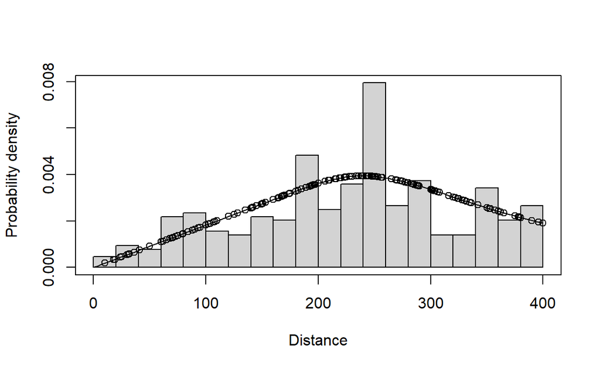

Figure 2: Northern bobwhite pooled detection function

```r
plot(nobopool, pdf=TRUE, nc=20)
```

# Dickcissel

## Each visit treated separately

```r
birds$Effort <- 1
mytruncation <- "15%"
dickcissel <- each.visit.alone(birds, "DICK", mytruncation, birdunits)
```

```
Error :
gosolnp-->Could not find a feasible starting point...exiting

Error : $ operator is invalid for atomic vectors
```

## Temporal estimate plot

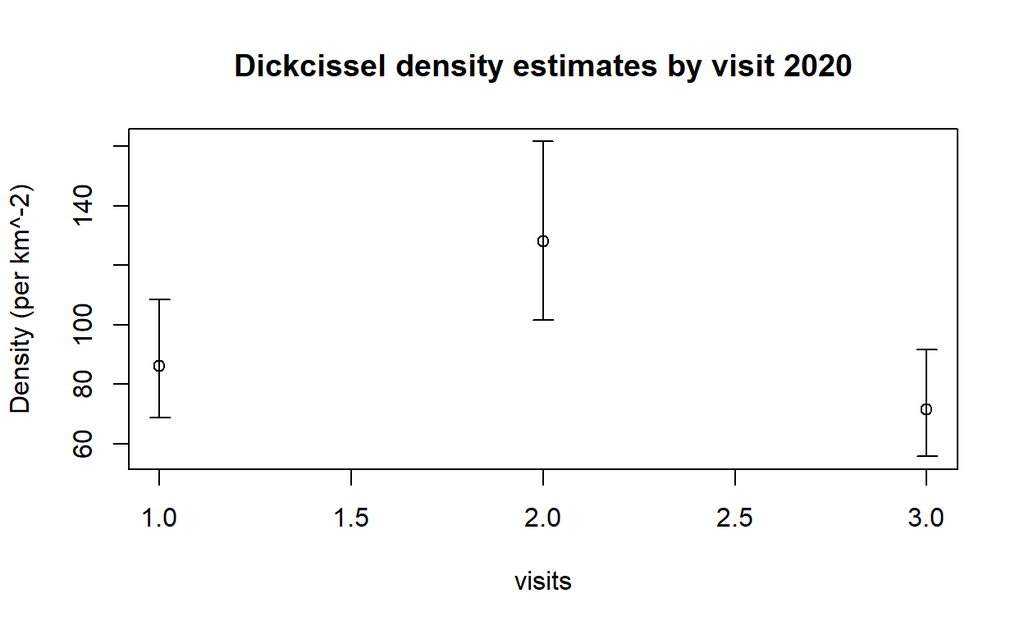

Figure 3: Dickcissel density estimates by time

```r
visits <- c(1,2,3)
plotCI(visits, dickcissel$Estimate, li=dickcissel$lcl, ui=dickcissel$ucl, ylab="Density (per km^-2)",
       main="Dickcissel density estimates by visit 2020")
```

## Density estimate pooling across visits

For this analysis, `Effort` must equal 3 to represent multiple visits. This analysis knows nothing about multiple visits like previous analyses that explicitly included treatment of `bout`.

```r
birds$Effort <- 3
dick <- birds[(birds$species=="DICK")  | is.na(birds$distance), ]
dickpool <- ds(data=dick,
                transect="point", key="hr",
                truncation = mytruncation, convert.units = birdunits)
```

```
Error :
gosolnp-->Could not find a feasible starting point...exiting

Error : $ operator is invalid for atomic vectors
```

```r
summary(dickpool)
```

```
Summary for distance analysis
Number of observations :  706
Distance range         :  0  -  124.5

Model : Hazard-rate key function
AIC   : 6609.708

Detection function parameters
Scale coefficient(s):
            estimate         se
(Intercept) 4.266529 0.05272575

Shape coefficient(s):
            estimate        se
(Intercept) 1.191867 0.1172692

                        Estimate          SE         CV
Average p              0.4998325  0.02755729 0.05513306
N in covered region 1412.4732887 86.47413371 0.06122178

Summary statistics:
  Region Area CoveredArea Effort   n   k       ER     se.ER
1   FRMR    1    14.75473    303 706 101 2.330033 0.1641389
       cv.ER
1 0.07044489

Abundance:
  Label Estimate       se         cv      lcl      ucl       df
1 Total 95.73022 8.563514 0.08945466 80.29387 114.1342 246.8678

Density:
  Label Estimate       se         cv      lcl      ucl       df
1 Total 95.73022 8.563514 0.08945466 80.29387 114.1342 246.8678
```

```r
cvmtest(dickpool)
```

```
[1] "CvM W= 0.254 P= 0.183"
```

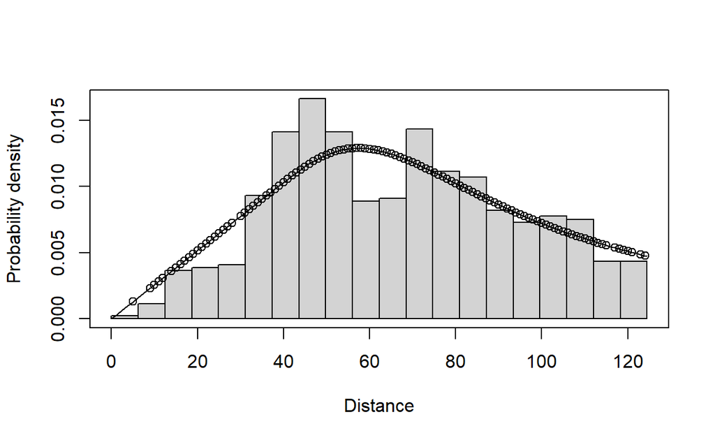

Figure 4: Dickcissel pooled detection function

```r
plot(dickpool, pdf=TRUE, nc=20)
```

# Brown headed cowbird

## Each visit treated separately

```r
birds$Effort <- 1
cowbird <- each.visit.alone(birds, "BHCO", mytruncation, birdunits)
```

## Temporal estimate plot

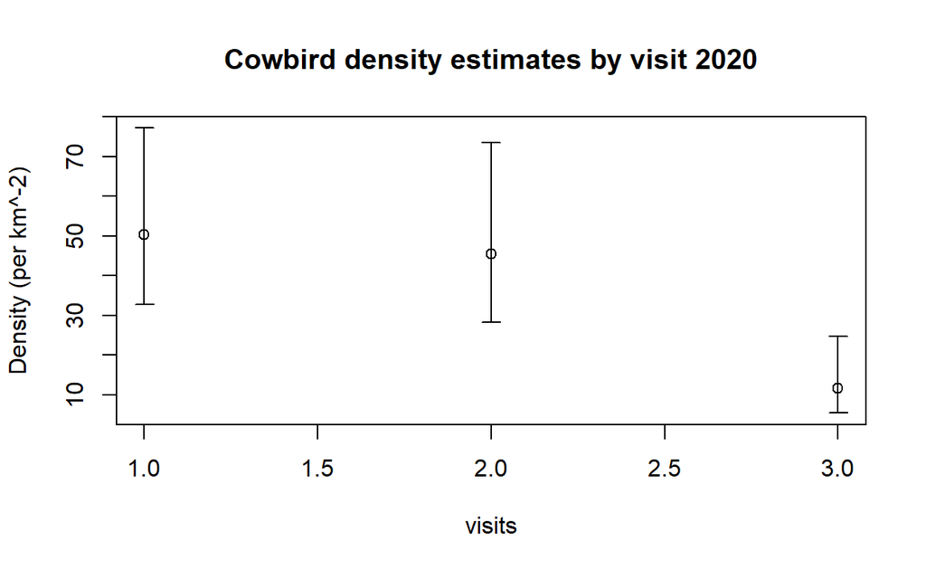

Figure 5: Cowbird density estimates by time

```r
plotCI(visits, cowbird$Estimate, li=cowbird$lcl, ui=cowbird$ucl, ylab="Density (per km^-2)",
       main="Cowbird density estimates by visit 2020")
```

## Density estimate pooling across visits

For this analysis, `Effort` must equal 3 to represent multiple visits. This analysis knows nothing about multiple visits like previous analyses that explicitly included treatment of `bout`.

```r
birds$Effort <- 3
bhco <- birds[(birds$species=="BHCO")  | is.na(birds$distance), ]
bhcopool <- ds(data=bhco,
                transect="point", key="hr",
                truncation = mytruncation, convert.units = birdunits)
summary(bhcopool)
```

```
Summary for distance analysis
Number of observations :  294
Distance range         :  0  -  166

Model : Hazard-rate key function
AIC   : 2928.484

Detection function parameters
Scale coefficient(s):
            estimate        se
(Intercept) 4.211973 0.1047826

Shape coefficient(s):
            estimate        se
(Intercept) 1.016834 0.1246812

                       Estimate           SE        CV
Average p             0.3233523   0.03604458 0.1114715
N in covered region 909.2250752 110.34047355 0.1213566

Summary statistics:
  Region Area CoveredArea Effort   n   k       ER     se.ER     cv.ER
1   FRMR    1    26.23063    303 294 101 0.970297 0.1035242 0.1066933

Abundance:
  Label Estimate       se        cv      lcl      ucl      df
1 Total 34.66273 5.348556 0.1543028 25.63192 46.87532 310.689

Density:
  Label Estimate       se        cv      lcl      ucl      df
1 Total 34.66273 5.348556 0.1543028 25.63192 46.87532 310.689
```

```r
cvmtest(bhcopool)
```

```
[1] "CvM W= 0.131 P= 0.452"
```

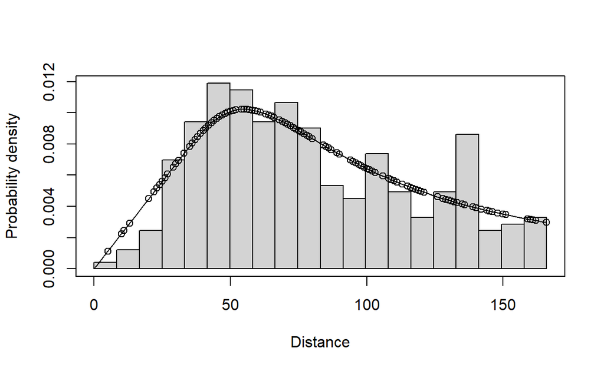

Figure 6: Brown headed cowbird pooled detection function

```r
plot(bhcopool, pdf=TRUE, nc=20)
```

# Eastern meadowlark

## Each visit treated separately

```r
birds$Effort <- 1
meadowlark <- each.visit.alone(birds, "EAME", mytruncation, birdunits)
```

```
Error :
gosolnp-->Could not find a feasible starting point...exiting

Error : $ operator is invalid for atomic vectors
```

## Temporal estimate plot

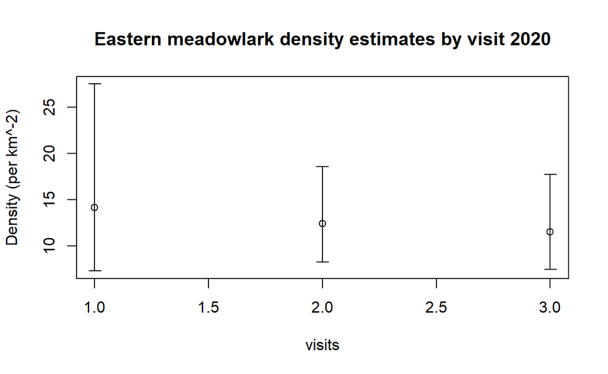

Figure 7: Eastern meadowlark density estimates by time

```r
plotCI(visits, meadowlark$Estimate, li=meadowlark$lcl, ui=meadowlark$ucl, ylab="Density (per km^-2)",
       main="Eastern meadowlark density estimates by visit 2020")
```

## Density estimate pooling across visits

For this analysis, `Effort` must equal 3 to represent multiple visits. This analysis knows nothing about multiple visits like previous analyses that explicitly included treatment of `bout`.

```r
birds$Effort <- 3
eame <- birds[(birds$species=="EAME")  | is.na(birds$distance), ]
eamepool <- ds(data=eame,
                transect="point", key="hr",
                truncation = mytruncation, convert.units = birdunits)
```

```
Error :
gosolnp-->Could not find a feasible starting point...exiting

Error : $ operator is invalid for atomic vectors
```

```r
summary(eamepool)
```

```
Summary for distance analysis
Number of observations :  266
Distance range         :  0  -  200

Model : Hazard-rate key function
AIC   : 2750.064

Detection function parameters
Scale coefficient(s):
            estimate        se
(Intercept) 4.789225 0.1263882

Shape coefficient(s):
             estimate       se
(Intercept) 0.9135837 0.236906

                       Estimate          SE        CV
Average p             0.5633093  0.06503219 0.1154467
N in covered region 472.2094710 57.77503230 0.1223504

Summary statistics:
  Region Area CoveredArea Effort   n   k        ER      se.ER
1   FRMR    1     38.0761    303 266 101 0.8778878 0.09366311
      cv.ER
1 0.1066914

Abundance:
  Label Estimate       se        cv      lcl     ucl       df
1 Total 12.40173 1.949518 0.1571973 9.119487 16.8653 310.1871

Density:
  Label Estimate       se        cv      lcl     ucl       df
1 Total 12.40173 1.949518 0.1571973 9.119487 16.8653 310.1871
```

```r
cvmtest(eamepool)
```

```
[1] "CvM W= 0.161 P= 0.358"
```

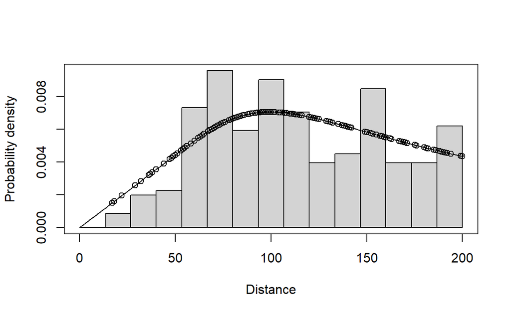

Figure 8: Eastern meadowlark pooled detection function

```r
plot(eamepool, pdf=TRUE, nc=15)
```

# Bell’s vireo

## Each visit treated separately

```r
birds$Effort <- 1
bellsvireo <- each.visit.alone(birds, "BEVI", mytruncation, birdunits)
```

```
Error in if (min(tempv) > 0) { : missing value where TRUE/FALSE needed
Error : $ operator is invalid for atomic vectors
```

## Temporal estimate plot

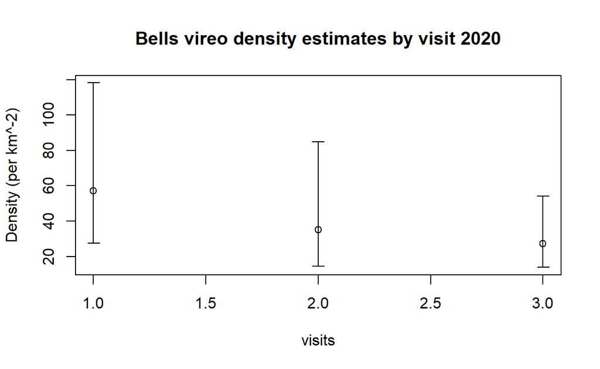

Figure 9: Bells vireo density estimates by time

```r
plotCI(visits, bellsvireo$Estimate, li=bellsvireo$lcl, ui=bellsvireo$ucl, ylab="Density (per km^-2)",
       main="Bells vireo density estimates by visit 2020")
```

## Density estimate pooling across visits

For this analysis, `Effort` must equal 3 to represent multiple visits. This analysis knows nothing about multiple visits like previous analyses that explicitly included treatment of `bout`.

```r
birds$Effort <- 3
bevi <- birds[(birds$species=="BEVI")  | is.na(birds$distance), ]
bevipool <- ds(data=bevi,
                transect="point", key="hr",
                truncation = mytruncation, convert.units = birdunits)
summary(bevipool)
```

```
Summary for distance analysis
Number of observations :  177
Distance range         :  0  -  118.8

Model : Hazard-rate key function
AIC   : 1664.079

Detection function parameters
Scale coefficient(s):
            estimate        se
(Intercept) 3.785883 0.2247865

Shape coefficient(s):
             estimate        se
(Intercept) 0.7110988 0.2009392

                       Estimate           SE        CV
Average p             0.3370078   0.06713853 0.1992195
N in covered region 525.2103291 109.45832796 0.2084086

Summary statistics:
  Region Area CoveredArea Effort   n   k        ER      se.ER
1   FRMR    1    13.43462    303 177 101 0.5841584 0.07011007
      cv.ER
1 0.1200189

Abundance:
  Label Estimate       se        cv      lcl      ucl      df
1 Total  39.0938 9.092394 0.2325789 24.87933 61.42951 264.182

Density:
  Label Estimate       se        cv      lcl      ucl      df
1 Total  39.0938 9.092394 0.2325789 24.87933 61.42951 264.182
```

```r
cvmtest(bevipool)
```

```
[1] "CvM W= 0.053 P= 0.858"
```

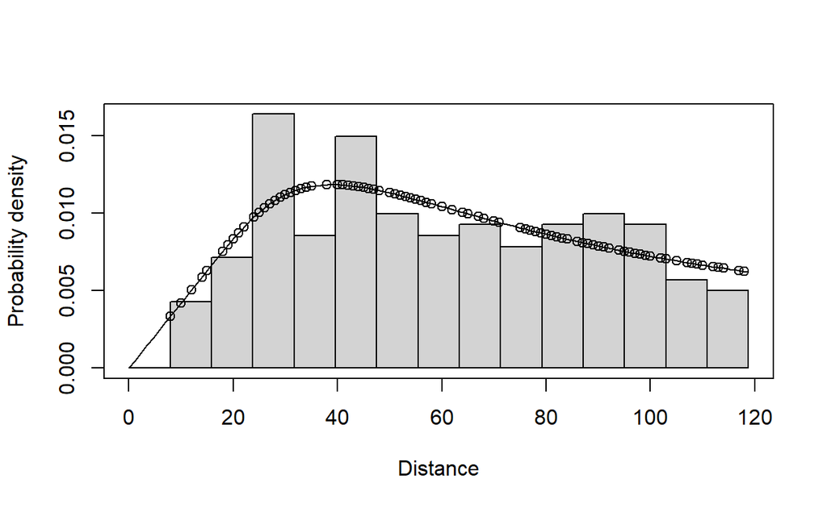

Figure 10: Bells vireo pooled detection function

```r
plot(bevipool, pdf=TRUE, nc=15)
```

# Henslow’s sparrow

There are too few detections in individual visits that per-visit density estimates seem unwarranted.

## Density estimate pooling across visits

For this analysis, `Effort` must equal 3 to represent multiple visits. This analysis knows nothing about multiple visits like previous analyses that explicitly included treatment of `bout`.

```r
birds$Effort <- 3
hesp <- birds[(birds$species=="HESP")  | is.na(birds$distance), ]
hesppool <- ds(data=hesp,
                transect="point", key="hr",
                truncation = mytruncation, convert.units = birdunits)
summary(hesppool)
```

```
Summary for distance analysis
Number of observations :  39
Distance range         :  0  -  80

Model : Hazard-rate key function
AIC   : 330.2512

Detection function parameters
Scale coefficient(s):
            estimate        se
(Intercept) 4.289201 0.3053963

Shape coefficient(s):
             estimate       se
(Intercept) 0.8734394 1.657544

                      Estimate         SE        CV
Average p            0.8214727  0.2260591 0.2751876
N in covered region 47.4757094 13.4538023 0.2833829

Summary statistics:
  Region Area CoveredArea Effort  n   k        ER      se.ER
1   FRMR    1    6.092176    303 39 101 0.1287129 0.03632463
      cv.ER
1 0.2822144

Abundance:
  Label Estimate       se        cv      lcl      ucl       df
1 Total 7.792898 3.071758 0.3941741 3.669739 16.54866 110.5214

Density:
  Label Estimate       se        cv      lcl      ucl       df
1 Total 7.792898 3.071758 0.3941741 3.669739 16.54866 110.5214
```

```r
cvmtest(hesppool)
```

```
[1] "CvM W= 0.084 P= 0.668"
```

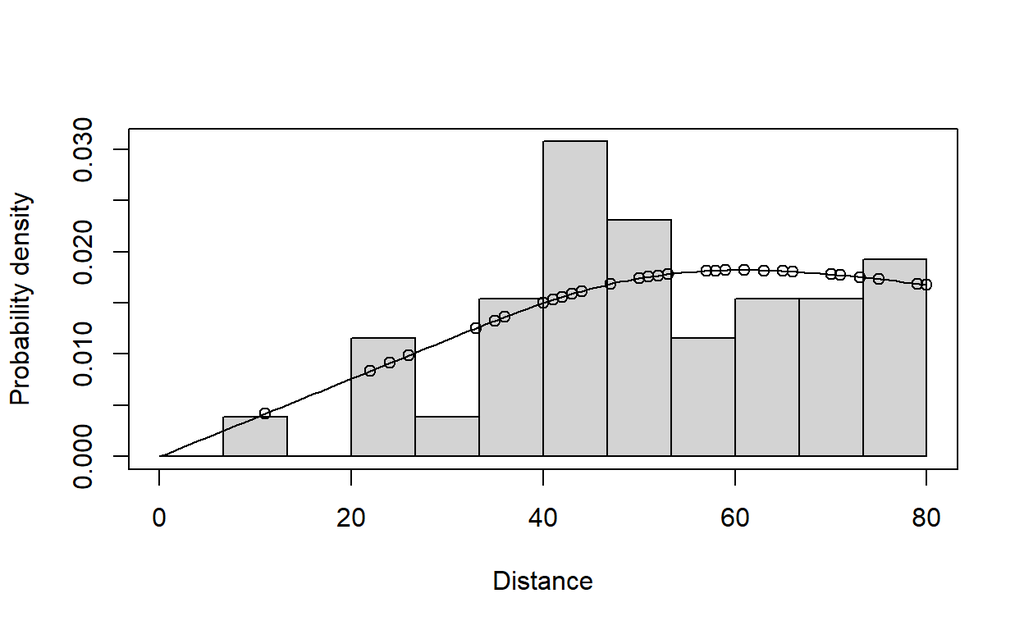

Figure 11: Henslows sparrow pooled detection function

```r
plot(hesppool, pdf=TRUE, nc=12)
```

# Ring-necked pheasant

There are too few detections in individual visits that per-visit density estimates seem unwarranted.

## Density estimate pooling across visits

For this analysis, `Effort` must equal 3 to represent multiple visits. This analysis knows nothing about multiple visits like previous analyses that explicitly included treatment of `bout`.

```r
birds$Effort <- 3
rnph <- birds[(birds$species=="RNPH")  | is.na(birds$distance), ]
rnphpool <- ds(data=rnph,
                transect="point", key="hr",
                truncation = mytruncation, convert.units = birdunits)
summary(rnphpool)
```

```
Summary for distance analysis
Number of observations :  41
Distance range         :  0  -  444

Model : Hazard-rate key function
AIC   : 486.1058

Detection function parameters
Scale coefficient(s):
            estimate         se
(Intercept) 6.016563 0.07958658

Shape coefficient(s):
            estimate       se
(Intercept) 4.158901 3.287068

                     Estimate         SE        CV
Average p            0.869444 0.08726127 0.1003645
N in covered region 47.156573 5.42962745 0.1151404

Summary statistics:
  Region Area CoveredArea Effort  n   k        ER      se.ER
1   FRMR    1    187.6543    303 41 101 0.1353135 0.02576795
      cv.ER
1 0.1904314

Abundance:
  Label Estimate         se        cv       lcl       ucl       df
1 Total 0.251295 0.05409392 0.2152607 0.1649688 0.3827947 136.3037

Density:
  Label Estimate         se        cv       lcl       ucl       df
1 Total 0.251295 0.05409392 0.2152607 0.1649688 0.3827947 136.3037
```

```r
cvmtest(rnphpool)
```

```
[1] "CvM W= 0.24 P= 0.202"
```

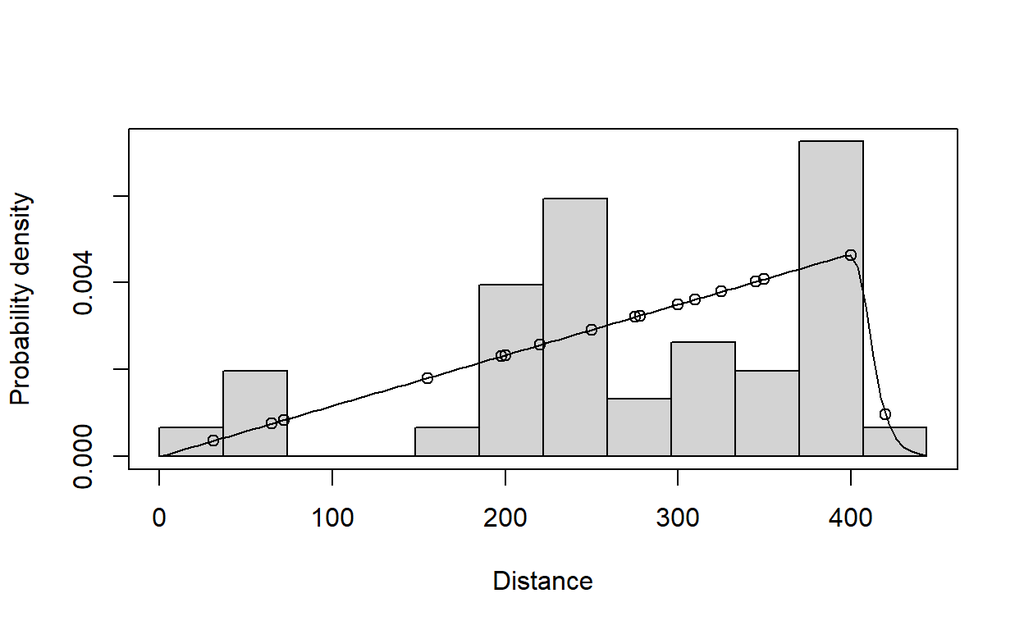

Figure 12: Ring necked pheasant pooled detection function

```r
plot(rnphpool, pdf=TRUE, nc=12)
```

# Density estimates across all species

```r
density.table <- rbind(hesppool$dht$individuals$D,
                       nobopool$dht$individuals$D,
                       rnphpool$dht$individuals$D,
                       dickpool$dht$individuals$D,
                       bhcopool$dht$individuals$D,
                       eamepool$dht$individuals$D,
                       bevipool$dht$individuals$D)
density.table$Label <- special.species
kable(density.table[, 1:6], caption="Density estimates (per square kilometer) from pooled detections for all species",
      row.names=FALSE, digits=4)
```

Table 2: Density estimates (per square kilometer) from pooled detections for all species

| Label | Estimate | se | cv | lcl | ucl |
| --- | --- | --- | --- | --- | --- |
| HESP | 7.7929 | 3.0718 | 0.3942 | 3.6697 | 16.5487 |
| NOBO | 3.0764 | 0.3285 | 0.1068 | 2.4946 | 3.7940 |
| RNPH | 0.2513 | 0.0541 | 0.2153 | 0.1650 | 0.3828 |
| DICK | 95.7302 | 8.5635 | 0.0895 | 80.2939 | 114.1342 |
| BHCO | 34.6627 | 5.3486 | 0.1543 | 25.6319 | 46.8753 |
| EAME | 12.4017 | 1.9495 | 0.1572 | 9.1195 | 16.8653 |
| BEVI | 39.0938 | 9.0924 | 0.2326 | 24.8793 | 61.4295 |

In plotted form

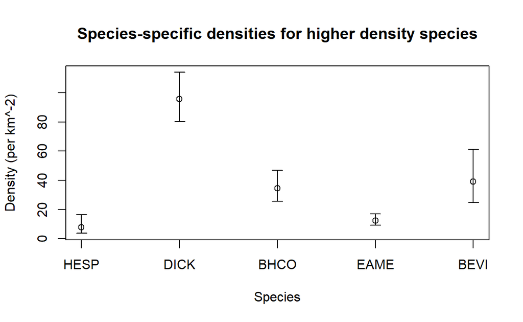

```r
plotCI(seq(1,5), density.table$Estimate[c(1,4:7)], li=density.table$lcl[c(1,4:7)],
       ui=density.table$ucl[c(1,4:7)], ylab="Density (per km^-2)", xlab="Species",
       main="Species-specific densities for higher density species",
       xaxt="n")
axis(side=1, at=seq(1,5), labels=special.species[c(1,4:7)], cex=0.8)
```